# Intensive blood pressure lowering reduces adverse cardiovascular outcomes among patients with high‐normal glucose: An analysis from the Systolic Blood Pressure Intervention Trial database - Gong - 201

## 3 RESULTS

Of the 9361 participants, 38 did not have baseline glucose data and were excluded. Of the 9323 remaining SPRINT participants with available fasting glucose values at baseline, 5425 had baseline fasting glucose of <100 mg/dL, including 852 with glucose of <85 mg/dL and 4573 with glucose of 85 to <100 mg/dL. The mean fasting plasma glucose concentrations were 80 and 93 mg/dL, respectively, within the 2 groups. Within each group, approximately 50% of patients were assigned to the intensive or standard BP target arms and the baseline characteristics of the participants were well balanced between the strategies (Table 1).

Table 1. Pertinent baseline characteristics of participants by baseline glucose level and randomization arm

[output not shown]

- Data represent mean ± SD or % where appropriate. *P* values were from *t* test for continuous variables and chi-square test for categorical variables.
- <sup>*a*</sup> eGFR: estimated glomerular filtration rate based on MDRD in mL/min/1.73 m<sup>2</sup>.
- <sup>*b*</sup> Subclinical CVD: coronary artery calcium score ≥400 Agaston unites within the past 2 years; or ankle brachial index ≤0.90 within the past 2 years; left ventricular hypertrophy by ECG, echocardiogram report, or other cardiac imaging procedure report within the past 2 years.

Overall, after an average follow-up of 3.1 years, there were no statistically significant differences in the percentage of participants who experienced a primary outcome event among those with low-normal glucose (4.81%) or high-normal glucose (6.01%) (*P* = .17). The intensive SBP target strategy was associated with lower risk for the primary outcome compared with the standard SBP target in those with high-normal glucose (log-rank *P* = .021). However, among participants with low-normal glucose, there was no evidence to suggest that the primary outcome risk was reduced comparing an intensive SBP target vs standard SBP target (log-rank *P* = .51) (Figure 1). The adjusted HR for the intensive vs standard SBP target strategy was 1.27 (95% confidence interval [CI] 0.68-2.37, *P* = .46) in patients with low-normal glucose, and 0.73 (95% CI, 0.57-0.93, *P* = .010) in participants with high-normal glucose (Figure 2). The test for interaction between treatment strategies and the 2 glucose groups was not significant (*P* = .16). We observed similar results evaluating the effect of intensive vs standard SBP targets and all-cause mortality in the high-normal glucose participants, with an adjusted HR of 0.70 (95% CI, 0.52-0.94; *P* = .018). In patients with low-normal glucose, the adjusted HR for all-cause mortality comparing the intensive vs standard SBP target was 0.73 (95% CI, 0.33-1.63; *P* = .45).

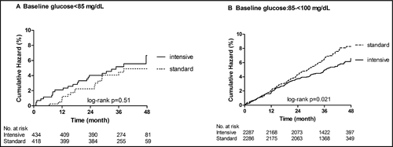

**Figure 1**

Kaplan Meier curve for primary outcome by treatment targets within each baseline glucose strata. Standard: standard SBP target arm; intensive: intensive SBP target arm. (A) Baseline glucose <85 mg/dL. (B) Baseline glucose of 85 to <100 mg/dL

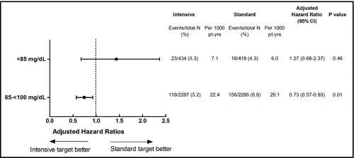

**Figure 2**

Adjusted hazard ratios for primary outcome in the intensive SBP target arm compared to the standard SBP target group

## 4 DISCUSSION

In this analysis of SPRINT data, we found that hypertensive participants with high-normal glucose benefited with reduction in CV risk and death from antihypertensive treatment targeting a SBP <120 mm Hg. A similar benefit was not observed among the participants with low-normal glucose, although such a benefit cannot be excluded given the wide confidence intervals for both outcomes in this group. Although large randomized trials and meta-analyses have been conducted among hypertensives with and without diabetes,6, 7 to our knowledge, the present study is the first to assess the impact of different BP targets among individuals without diabetes or impaired fasting glucose.

The 2017 High Blood Pressure Clinical Practice Guideline recommends a BP target <130/80 mm Hg for all patients with hypertension, without regard to glucose level.16 Our current analysis provides evidence to support the recommendation that an intensive SBP target is advisable for hypertensive individuals with fasting glucose levels in the high-normal range (≥85 to <100 mg/dL). Furthermore, these data accord with recently published data from SPRINT, reaching a similar conclusion for hypertensive participants with prediabetes (≥100 mg/dL).13 Although the recent guidelines do not explicitly consider glucose levels in determining a need for more aggressive BP reduction, these data, taken together, appear to provide support for the use of more intensive SBP targets in anyone with fasting glucose levels ≥85 mg/dL.

Unfortunately, our data do not allow for drawing definitive conclusions from the relatively small subset of patients with low-normal glucose levels. Therefore, in order to provide consistent public health messaging in the absence of definitive data, it seems reasonable to also use the more intensive SBP target in this population. However, it should also be noted that the 2017 High Blood Pressure Clinical Practice Guideline16 specifies not only updated definition of hypertension, but also thresholds for when to begin BP-lowering treatment. Specifically, the guidelines state that patients with stage I hypertension (eg, SBP 130 to <140) and an Atherosclerotic Cardiovascular Disease (ASCVD) 10-year risk <10% do not necessarily require antihypertensive therapy to achieve an SBP < 130 mm Hg. SPRINT, by definition, enrolled a relatively high-risk hypertensive population, including high-risk patients with low-normal glucose. However, in the real world, without the constraints of clinical trial eligibility criteria, hypertensive patients with low-normal glucose are likely to have comparatively lower ASCVD risk than patients with higher fasting glucose. Future research will need to explore the benefits and risks associated with more aggressive BP targets in this lower risk population.

Our study has some limitations. First, this is a post-hoc analysis, even though the randomization strategy appears largely intact within the 2 strata of baseline fasting glucose, this was not a pre-specified analysis. Second, the sample size in the low-normal glucose group was relatively small and was underpowered. The lack of benefit of the intensive SBP target in the low-normal glucose group requires further conformation in light of the low sample size. However, if confirmed, inclusion of glucose level as a biomarker in the personalization of BP targets may be important in light of the potential risks associated with additional antihypertensive drug exposure. Finally, since SPRINT study enrolled individuals with increased risk for CV events, these results may not be generalizable to all hypertensive patients within the normal fasting glucose range.

## ACKNOWLEDGMENTS

We acknowledge all of the SPRINT Project investigators and participants for their contribution and the NEJM SPRINT data analysis challenge committee, since without their work this analysis would not have been possible.

## CONFLICT OF INTEREST

The authors declare no conflict of interest associated with this manuscript.

[figure not shown]

[figure not shown]